# Marketing Campaign for a Housing Subsidy

Ben Keel

2022-11-04

# Motivation for Analysis

Develop and interpret data visualizations that describe feature importance/correlation.

# Important Features

## Current Features

Develop and interpret data visualizations that describe feature importance/correlation.

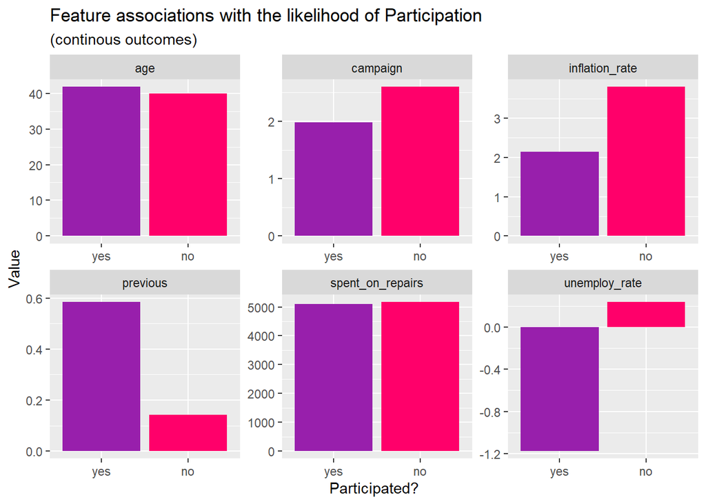

```r
subsidy %>%
  dplyr::select(y, age, spent_on_repairs, inflation_rate, unemploy_rate, previous, campaign) %>%
  gather(Variable, value, -y) %>%
    ggplot(aes(y, value, fill=y)) +
      geom_bar(position = "dodge", stat = "summary", fun = "mean") +
      facet_wrap(~Variable, scales = "free") +
      scale_fill_manual(values = palette2) +
      labs(x="Participated?", y="Value",
           title = "Feature associations with the likelihood of Participation",
           subtitle = "(continous outcomes)") +
      theme(legend.position = "none")
```

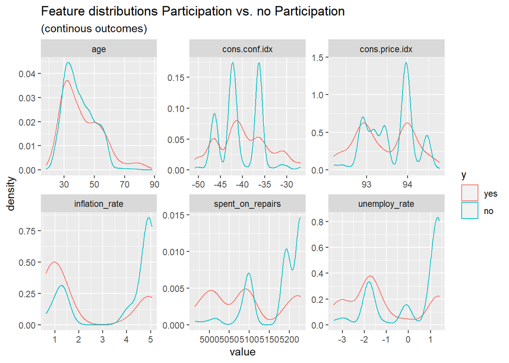

```r
subsidy %>%
    dplyr::select(y, age, cons.conf.idx, cons.price.idx, unemploy_rate, inflation_rate, spent_on_repairs) %>%
    gather(Variable, value, -y) %>%
    ggplot() +
    geom_density(aes(value, color=y), fill = "transparent") +
    facet_wrap(~Variable, scales = "free") +
    scale_fill_manual(values = palette2) +
    labs(title = "Feature distributions Participation vs. no Participation",
         subtitle = "(continous outcomes)",
         legend.title= "Result")
```

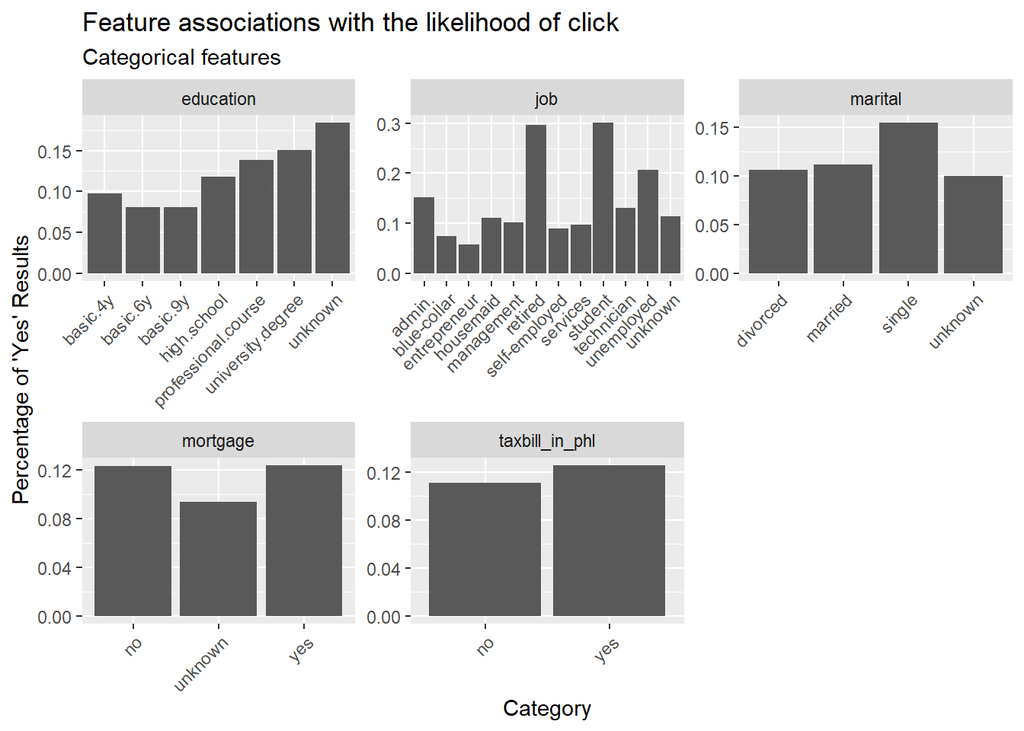

```r
#Rate Graphs
subsidy %>%
    dplyr::select(y, job, marital, education, mortgage, taxbill_in_phl) %>%
    gather(Variable, value, -y) %>%
    count(Variable, value, y) %>%
    group_by(Variable) %>%
      mutate(rate = lag(n)/n)%>%
    filter(y == "no" & value != "illiterate")%>%
      ggplot(., aes(value, rate)) +
        geom_bar(position = "dodge", stat="identity") +
        facet_wrap(~Variable, scales="free") +
        labs(x="Category", y="Percentage of 'Yes' Results",
             title = "Feature associations with the likelihood of click",
             subtitle = "Categorical features") +
        theme(axis.text.x = element_text(angle = 45, hjust = 1))
```

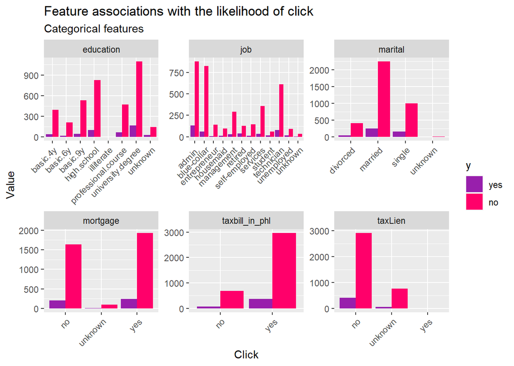

```r
#Quantity Graphs
subsidy %>%
    dplyr::select(y, job, marital, education, taxLien, mortgage, taxbill_in_phl) %>%
    gather(Variable, value, -y) %>%
    count(Variable, value, y) %>%
      ggplot(., aes(value, n, fill = y)) +
        geom_bar(position = "dodge", stat="identity") +
        facet_wrap(~Variable, scales="free") +
        scale_fill_manual(values = palette2) +
        labs(x="Click", y="Value",
             title = "Feature associations with the likelihood of click",
             subtitle = "Categorical features") +
        theme(axis.text.x = element_text(angle = 45, hjust = 1))
```

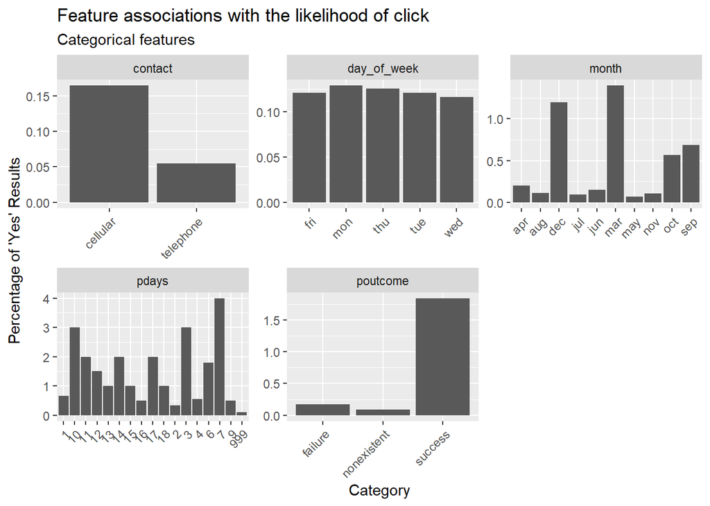

```r
#Rate Graphs
subsidy %>%
    dplyr::select(y, contact, pdays, month, day_of_week, poutcome) %>%
    gather(Variable, value, -y) %>%
    count(Variable, value, y)%>%
  mutate(rate = lag(n)/n)%>%
    filter(y=="no")%>%
      ggplot(., aes(value, rate)) +
        geom_bar(position = "dodge", stat="identity") +
        facet_wrap(~Variable, scales="free") +
        labs(x="Category", y="Percentage of 'Yes' Results",
             title = "Feature associations with the likelihood of click",
             subtitle = "Categorical features") +
        theme(axis.text.x = element_text(angle = 45, hjust = 1))
```

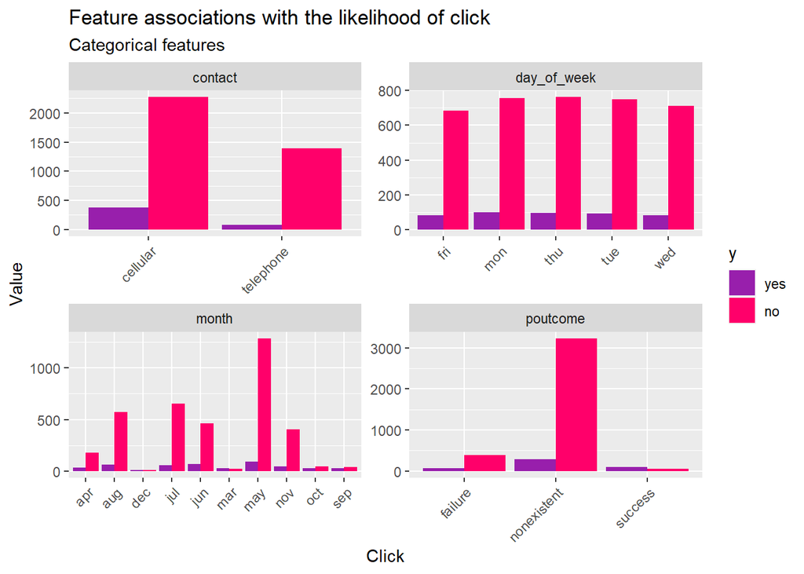

```r
#Quantity Graphs
subsidy %>%
    dplyr::select(y, contact, month, day_of_week, poutcome) %>%
    gather(Variable, value, -y) %>%
    count(Variable, value, y) %>%
      ggplot(., aes(value, n, fill = y)) +
        geom_bar(position = "dodge", stat="identity") +
        facet_wrap(~Variable, scales="free") +
        scale_fill_manual(values = palette2) +
        labs(x="Click", y="Value",
             title = "Feature associations with the likelihood of click",
             subtitle = "Categorical features") +
        theme(axis.text.x = element_text(angle = 45, hjust = 1))
```

## Data Split + Modeling

Split your data into a 65/35 training/test set.

```r
set.seed(999)
trainIndex <- createDataPartition(subsidy$y, p = .65,
                                  list = FALSE,
                                  times = 1)
subsidyTrain <- subsidy[ trainIndex,]
subsidyTest  <- subsidy[-trainIndex,]

subsidyModel <- glm(y_numeric ~ .,
                  data=subsidyTrain %>%
                    dplyr::select(-y),
                  family="binomial" (link="logit"))

summary(subsidyModel)
```

```
##
## Call:
## glm(formula = y_numeric ~ ., family = binomial(link = "logit"),
##     data = subsidyTrain %>% dplyr::select(-y))
##
## Deviance Residuals:
##     Min       1Q   Median       3Q      Max
## -2.1985  -0.4061  -0.3227  -0.2467   2.9743
##
## Coefficients:
##                                   Estimate    Std. Error z value Pr(>|z|)
## (Intercept)                  -118.28934825  134.00038703  -0.883 0.377369
## X                               0.00003332    0.00006082   0.548 0.583764
## age                             0.01589797    0.00869934   1.827 0.067626 .
## jobblue-collar                 -0.51005525    0.28210616  -1.808 0.070602 .
## jobentrepreneur                -0.40851806    0.46960753  -0.870 0.384348
## jobhousemaid                   -0.59792320    0.56156418  -1.065 0.286991
## jobmanagement                  -0.59286735    0.32410900  -1.829 0.067366 .
## jobretired                      0.15397407    0.36761552   0.419 0.675329
## jobself-employed               -0.97879612    0.46102702  -2.123 0.033747 *
## jobservices                    -0.18946516    0.29176526  -0.649 0.516096
## jobstudent                     -0.19374300    0.43570276  -0.445 0.656560
## jobtechnician                   0.19420877    0.23490119   0.827 0.408369
## jobunemployed                  -0.02928047    0.41777180  -0.070 0.944124
## jobunknown                     -0.71806446    0.81504508  -0.881 0.378311
## maritalmarried                  0.45392068    0.26884326   1.688 0.091330 .
## maritalsingle                   0.57257473    0.30577958   1.873 0.061136 .
## maritalunknown                -11.19570301  352.58267155  -0.032 0.974669
## educationbasic.6y               0.16654504    0.41304609   0.403 0.686792
## educationbasic.9y               0.14502029    0.32868428   0.441 0.659058
## educationhigh.school           -0.05276501    0.32691447  -0.161 0.871776
## educationilliterate           -13.38130940  882.74356614  -0.015 0.987906
## educationprofessional.course   -0.15021330    0.35560632  -0.422 0.672722
## educationuniversity.degree     -0.01568988    0.32870960  -0.048 0.961930
## educationunknown                0.14226844    0.43208433   0.329 0.741959
## taxLienunknown                  0.21835618    0.21338194   1.023 0.306161
## taxLienyes                    -11.58548616  882.74355395  -0.013 0.989529
## mortgageunknown                 0.14395041    0.53766527   0.268 0.788905
## mortgageyes                    -0.02871418    0.14672352  -0.196 0.844843
## taxbill_in_phlyes               0.16023631    0.20199185   0.793 0.427614
```

[output cut: 19 more lines]

```
## unemploy_rate                  -1.00679840    0.50976666  -1.975 0.048266 *
## cons.price.idx                  1.31243570    0.88632676   1.481 0.138671
## cons.conf.idx                   0.02657051    0.02855605   0.930 0.352129
## inflation_rate                  0.36327125    0.45574043   0.797 0.425392
## spent_on_repairs               -0.00152468    0.01082439  -0.141 0.887983
## ---
## Signif. codes:  0 '***' 0.001 '**' 0.01 '*' 0.05 '.' 0.1 ' ' 1
##
## (Dispersion parameter for binomial family taken to be 1)
##
##     Null deviance: 1853.7  on 2678  degrees of freedom
## Residual deviance: 1432.8  on 2626  degrees of freedom
## AIC: 1538.8
##
## Number of Fisher Scoring iterations: 13
```

```r
regSubsidySummary <-
  tidy(pR2(subsidyModel))%>%
  mutate(Regression = "Kitchen Sink")
```

```
## fitting null model for pseudo-r2
```

```r
regSubsidySummary%>%
  filter(names=="McFadden")%>%
  rename(Value = x,
         Measure = names)%>%
    kable(
    caption = "<strong></strong>",
    escape= FALSE,
    format="html",
    row.names = FALSE,
    align="l")%>%
  kable_styling()
```

| Measure | Value | Regression |
| --- | --- | --- |
| McFadden | 0.2270851 | Kitchen Sink |

# New Features

The Sensitivity (True Positive Rate) for a model with all the features is very low. Engineer new features that significantly increase the Sensitivity.

## List

Interpret your new features in one paragraph.

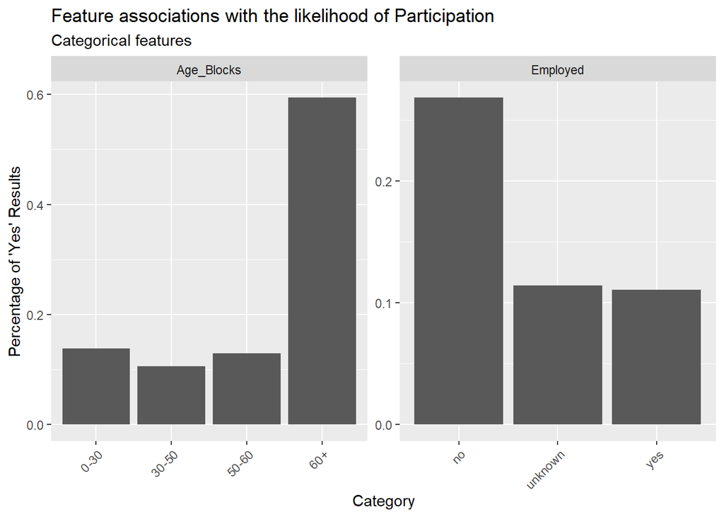

```r
#Engineer new features
##Summarize job as currently working vs not working.
subsidyRevised <-
  subsidy%>%
  mutate(Repairs_4800up = spent_on_repairs-4800,
         Employed = ifelse(job == "unknown", "unknown",
                    ifelse (job == "student" |
                      job == "retired" | job == "unemployed", "no", "yes")),
         Age_Blocks = ifelse(age>60 | age == 60, "60+",
                             ifelse(age < 60 & age > 50, "50-60",
                             ifelse(age < 51 & age > 29, "30-50",
                                    ifelse(age < 30, "0-30", "unknown")))),
         ActiveMonths = ifelse(month == "mar", "high",
                      ifelse(month == "nov" | month == "jun" | month == "may", "med", "low")))



#Show DV for these features
subsidyRevised %>%
    dplyr::select(y, Employed, Age_Blocks) %>%
    gather(Variable, value, -y) %>%
    count(Variable, value, y)%>%
  mutate(rate = lag(n)/n)%>%
    filter(y=="no")%>%
      ggplot(., aes(value, rate)) +
        geom_bar(position = "dodge", stat="identity") +
        facet_wrap(~Variable, scales="free") +
        labs(x="Category", y="Percentage of 'Yes' Results",
             title = "Feature associations with the likelihood of Participation",
             subtitle = "Categorical features") +
        theme(axis.text.x = element_text(angle = 45, hjust = 1))
```

## Regression Summary

Show a regression summary for both the kitchen sink and your engineered regression.

```r
set.seed(999)
trainIndexRevised <- createDataPartition(subsidyRevised$y, p = .65,
                                  list = FALSE,
                                  times = 1)
subsidyTrainRev <- subsidyRevised[ trainIndex,]
subsidyTestRev  <- subsidyRevised[-trainIndex,]

#Make new regression for engineered model
subsidyModelRev <- glm(y_numeric ~ .,
                  data=subsidyTrainRev %>%
                    dplyr::select(y_numeric, Repairs_4800up, campaign, ActiveMonths, poutcome, contact, cons.price.idx, cons.conf.idx,unemploy_rate, Age_Blocks, mortgage),
                  family="binomial" (link="logit"))

#Compare new and old models
summary(subsidyModelRev)
```

```
##
## Call:
## glm(formula = y_numeric ~ ., family = binomial(link = "logit"),
##     data = subsidyTrainRev %>% dplyr::select(y_numeric, Repairs_4800up,
##         campaign, ActiveMonths, poutcome, contact, cons.price.idx,
##         cons.conf.idx, unemploy_rate, Age_Blocks, mortgage))
##
## Deviance Residuals:
##     Min       1Q   Median       3Q      Max
## -1.9680  -0.4020  -0.3294  -0.2713   2.8484
##
## Coefficients:
##                        Estimate  Std. Error z value        Pr(>|z|)
## (Intercept)         -179.478303   33.652499  -5.333 0.0000000964528 ***
## Repairs_4800up         0.007065    0.003276   2.157        0.031044 *
## campaign              -0.052283    0.038798  -1.348        0.177802
## ActiveMonthslow       -1.824044    0.412831  -4.418 0.0000099445136 ***
## ActiveMonthsmed       -2.105943    0.413809  -5.089 0.0000003596311 ***
## poutcomenonexistent    0.323568    0.210004   1.541        0.123373
## poutcomesuccess        2.013039    0.303575   6.631 0.0000000000333 ***
## contacttelephone      -1.075024    0.238452  -4.508 0.0000065334438 ***
## cons.price.idx         1.909105    0.352630   5.414 0.0000000616671 ***
## cons.conf.idx          0.058869    0.015418   3.818        0.000134 ***
## unemploy_rate         -1.153739    0.224969  -5.128 0.0000002921688 ***
## Age_Blocks30-50        0.361329    0.214908   1.681        0.092701 .
## Age_Blocks50-60        0.540733    0.262196   2.062        0.039177 *
## Age_Blocks60+          0.907849    0.345062   2.631        0.008514 **
## mortgageunknown       -0.024538    0.495512  -0.050        0.960505
## mortgageyes            0.004423    0.142985   0.031        0.975325
## ---
## Signif. codes:  0 '***' 0.001 '**' 0.01 '*' 0.05 '.' 0.1 ' ' 1
##
## (Dispersion parameter for binomial family taken to be 1)
##
##     Null deviance: 1853.7  on 2678  degrees of freedom
## Residual deviance: 1469.2  on 2663  degrees of freedom
## AIC: 1501.2
##
## Number of Fisher Scoring iterations: 6
```

```r
stargazer(subsidyModelRev, type="text")
```

```
##
## ===============================================
##                         Dependent variable:
##                     ---------------------------
##                              y_numeric
## -----------------------------------------------
## Repairs_4800up                0.007**
##                               (0.003)
##
## campaign                      -0.052
##                               (0.039)
##
## ActiveMonthslow              -1.824***
##                               (0.413)
##
## ActiveMonthsmed              -2.106***
##                               (0.414)
##
## poutcomenonexistent            0.324
##                               (0.210)
##
## poutcomesuccess              2.013***
##                               (0.304)
##
## contacttelephone             -1.075***
##                               (0.238)
##
## cons.price.idx               1.909***
##                               (0.353)
##
## cons.conf.idx                0.059***
##                               (0.015)
##
## unemploy_rate                -1.154***
##                               (0.225)
##
## Age_Blocks30-50               0.361*
##                               (0.215)
##
## Age_Blocks50-60               0.541**
##                               (0.262)
##
## Age_Blocks60+                0.908***
##                               (0.345)
##
## mortgageunknown               -0.025
##                               (0.496)
##
## mortgageyes                    0.004
##                               (0.143)
##
## Constant                    -179.478***
##                              (33.652)
##
## -----------------------------------------------
## Observations                   2,679
## Log Likelihood               -734.582
## Akaike Inf. Crit.            1,501.164
## ===============================================
## Note:               *p<0.1; **p<0.05; ***p<0.01
```

```r
tidy(pR2(subsidyModelRev))%>%
mutate(Regression = "Engineered")%>%
rbind(regSubsidySummary)%>%
filter(names == "McFadden")%>%
dplyr::select(-names)%>%
rename(McFadden_R2 = x)%>%
  kable(
  caption = "<strong></strong>",
  escape= FALSE,
  format="html",
  row.names = FALSE,
  align="l")%>%
kable_styling()
```

```
## fitting null model for pseudo-r2
```

| McFadden_R2 | Regression |
| --- | --- |
| 0.2074603 | Engineered |
| 0.2270851 | Kitchen Sink |

## CV + Comparison

Cross validate both models; compare and interpret two facetted plots of ROC, Sensitivity and Specificity.

```r
#ROC, Sensitivity, Specificity
ctrl <- trainControl(method = "cv", number = 100, classProbs=TRUE, summaryFunction=twoClassSummary)

cvFit <- train(y ~ .,
                  data=subsidy %>%
                    dplyr::select(-y_numeric),
                method="glm", family="binomial",
                metric="ROC", trControl = ctrl)

cvFit
```

```
## Generalized Linear Model
##
## 4119 samples
##   20 predictor
##    2 classes: 'yes', 'no'
##
## No pre-processing
## Resampling: Cross-Validated (100 fold)
## Summary of sample sizes: 4077, 4077, 4078, 4078, 4077, 4079, ...
## Resampling results:
##
##   ROC        Sens   Spec
##   0.7612759  0.223  0.9811637
```

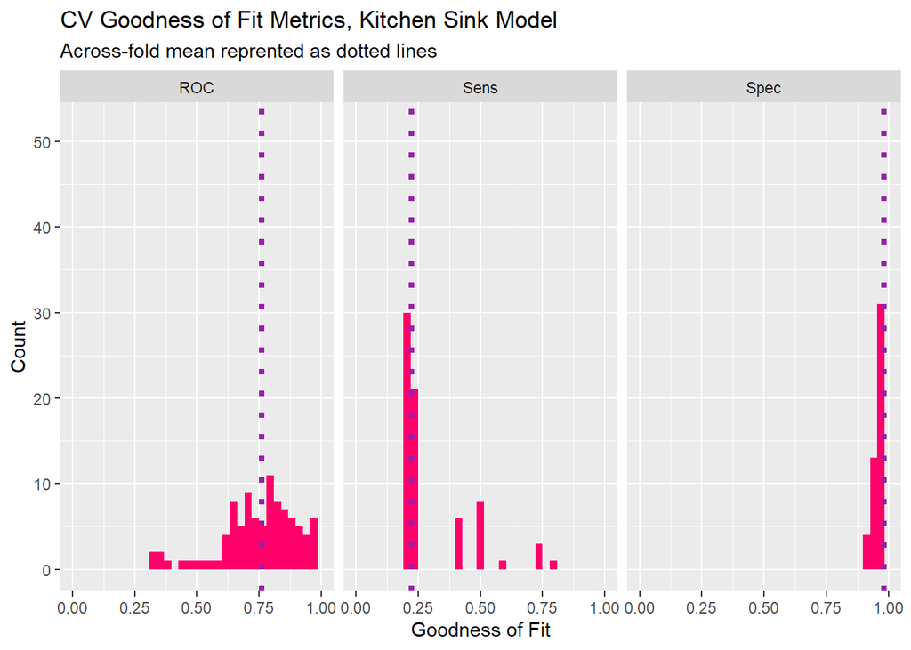

```r
#Goodness of Fit Metrics
dplyr::select(cvFit$resample, -Resample) %>%
  gather(metric, value) %>%
  left_join(gather(cvFit$results[2:4], metric, mean)) %>%
  ggplot(aes(value)) +
    geom_histogram(bins=35, fill = "#FF006A") +
    facet_wrap(~metric) +
    geom_vline(aes(xintercept = mean), colour = "#981FAC", linetype = 3, size = 1.5) +
    scale_x_continuous(limits = c(0, 1)) +
    labs(x="Goodness of Fit", y="Count", title="CV Goodness of Fit Metrics, Kitchen Sink Model",
         subtitle = "Across-fold mean reprented as dotted lines")
```

```r
#ROC, Sensitivity, Specificity
cvFitRevised <- train(y ~ .,
                  data=subsidyRevised %>%
                    dplyr::select(y, Repairs_4800up, unemploy_rate, campaign, ActiveMonths, poutcome, contact, cons.price.idx, cons.conf.idx, Age_Blocks, mortgage),
                method="glm", family="binomial",
                metric="ROC", trControl = ctrl)

cvFitRevised
```

```
## Generalized Linear Model
##
## 4119 samples
##   10 predictor
##    2 classes: 'yes', 'no'
##
## No pre-processing
## Resampling: Cross-Validated (100 fold)
## Summary of sample sizes: 4077, 4079, 4079, 4077, 4077, 4078, ...
## Resampling results:
##
##   ROC        Sens    Spec
##   0.7862292  0.2195  0.985
```

[figure not shown]

```r
#Goodness of Fit Metrics
dplyr::select(cvFitRevised$resample, -Resample) %>%
  gather(metric, value) %>%
  left_join(gather(cvFit$results[2:4], metric, mean)) %>%
  ggplot(aes(value)) +
    geom_histogram(bins=35, fill = "#FF006A") +
    facet_wrap(~metric) +
    geom_vline(aes(xintercept = mean), colour = "#981FAC", linetype = 3, size = 1.5) +
    scale_x_continuous(limits = c(0, 1)) +
    labs(x="Goodness of Fit", y="Count", title="CV Goodness of Fit Metrics, Engineered Model",
         subtitle = "Across-fold mean reprented as dotted lines")
```

# Usefulness of New Model (ROC)

Output an ROC curve for your new model and interpret it.

```r
testProbs <- data.frame(Outcome = as.factor(subsidyTestRev$y_numeric),
                        Probs = predict(subsidyModelRev, subsidyTestRev, type= "response"))

testProbs <-
  testProbs %>%
  mutate(predOutcome  = as.factor(ifelse(testProbs$Probs > 0.5 , 1, 0)))

caret::confusionMatrix(testProbs$predOutcome, testProbs$Outcome,
                       positive = "1")
```

```
## Confusion Matrix and Statistics
##
##           Reference
## Prediction    0    1
##          0 1260  119
##          1   23   38
##
##                Accuracy : 0.9014
##                  95% CI : (0.8848, 0.9163)
##     No Information Rate : 0.891
##     P-Value [Acc > NIR] : 0.109
##
##                   Kappa : 0.3063
##
##  Mcnemar's Test P-Value : 0.000000000000001558
##
##             Sensitivity : 0.24204
##             Specificity : 0.98207
##          Pos Pred Value : 0.62295
##          Neg Pred Value : 0.91371
##              Prevalence : 0.10903
##          Detection Rate : 0.02639
##    Detection Prevalence : 0.04236
##       Balanced Accuracy : 0.61206
##
##        'Positive' Class : 1
##
```

```r
auc(testProbs$Outcome, testProbs$Probs)
```

```
## Area under the curve: 0.8121
```

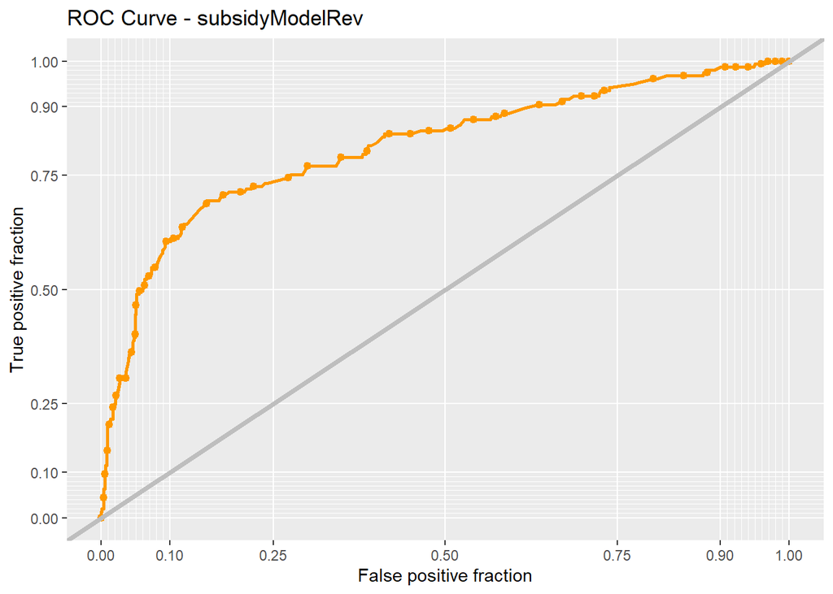

```r
ggplot(testProbs, aes(d = as.numeric(Outcome), m = Probs)) +
  geom_roc(n.cuts = 50, labels = FALSE, colour = "#FE9900") +
  style_roc(theme = theme_grey) +
  geom_abline(slope = 1, intercept = 0, size = 1.5, color = 'grey') +
  labs(title = "ROC Curve - subsidyModelRev")
```

# Cost Benefit Analysis

Develop a cost benefit analysis.

## Equations

Write out the cost/benefit equation for each confusion metric.

**True Negative Revenue** “We predicted citizen would not participate in the credit program, did not allocate marketing resources toward them. Citizen did not participate in the program, no credit allocated.”

$0

**False Positive Revenue** “We predicted citizen would participate in credit program, allocated marketing resources toward them ($2850 cost). citizen did not participate the credit program.”

-$2850

**False Negative Revenue** “Predicted citizen would not participate in the credit program, did not allocate marketing resources. Citizen participated in the program no cost to the campaign.”

$0

## Table of Costs and Benefits

Create the ‘Cost/Benefit Table’ as seen above.

```r
cost_benefit_table <-
   testProbs %>%
      count(predOutcome, Outcome) %>%
      summarize(True_Negative = sum(n[predOutcome==0 & Outcome==0]),
                True_Positive = sum(n[predOutcome==1 & Outcome==1]),
                False_Negative = sum(n[predOutcome==0 & Outcome==1]),
                False_Positive = sum(n[predOutcome==1 & Outcome==0])) %>%
       gather(Variable, Count) %>%
       mutate(Revenue =
               ifelse(Variable == "True_Negative", Count * 0,
               ifelse(Variable == "True_Positive",(
                 (-2850 + #marketing cost
                  0.25*(-5000 #successful participation and subsidy
                 +((10000+56000)*0.02 #property tax
                 +(10000+56000)*0.10*0.05) #real estate transfer tax
                 *15)) #applied over 15 years
                 * Count),
               ifelse(Variable == "False_Negative", Count * 0,
               ifelse(Variable == "False_Positive", (-2850) * Count, 0))))) %>%
    bind_cols(data.frame(Description = c(
              "We correctly predicted no participation",
              "We correctly predicted participation, with 25% receiving subsidy",
              "We predicted no particiption and the citizen pariticpated",
              "We predicted particiption and citizen did not participate")))

kable(cost_benefit_table,
       caption = "Cost/Benefit Table") %>% kable_styling()
```

Cost/Benefit Table

| Variable | Count | Revenue | Description |
| --- | --- | --- | --- |
| True_Negative | 1260 | 0 | We correctly predicted no participation |
| True_Positive | 38 | 79325 | We correctly predicted participation, with 25% receiving subsidy |
| False_Negative | 119 | 0 | We predicted no particiption and the citizen pariticpated |
| False_Positive | 23 | -65550 | We predicted particiption and citizen did not participate |

## Confusion Metrics

Plot the confusion metric outcomes for each Threshold.

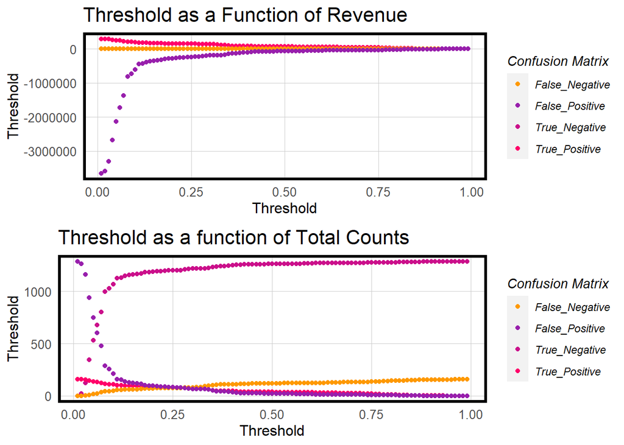

```r
iterateThresholds <- function(data) {
  x = .01
  all_prediction <- data.frame()
  while (x <= 1) {

  this_prediction <-
      testProbs %>%
      mutate(predOutcome = ifelse(Probs > x, 1, 0)) %>%
      count(predOutcome, Outcome) %>%
      summarize(True_Negative = sum(n[predOutcome==0 & Outcome==0]),
                True_Positive = sum(n[predOutcome==1 & Outcome==1]),
                False_Negative = sum(n[predOutcome==0 & Outcome==1]),
                False_Positive = sum(n[predOutcome==1 & Outcome==0])) %>%
     gather(Variable, Count) %>%
     mutate(Revenue =
               ifelse(Variable == "True_Negative", Count * 0,
               ifelse(Variable == "True_Positive",((-2850
                                                  + 0.25*(-5000
                                                  + ((10000+56000)*0.02
                                                  + (10000+56000)*0.10*0.04)
                                                  *15))
                                                  * Count),
               ifelse(Variable == "False_Negative", (0) * Count,
               ifelse(Variable == "False_Positive", (-2850) * Count, 0)))),
            Threshold = x)

  all_prediction <- rbind(all_prediction, this_prediction)
  x <- x + .01
  }
return(all_prediction)
}

whichThreshold <- iterateThresholds(testProbs2)

#Revenue Confusion Matrix Plot
revThresholdPlot <- whichThreshold %>%
  ggplot(.,aes(Threshold, Revenue, colour = Variable)) +
  geom_point() +
  scale_colour_manual(values = palette5[c(5, 1:3)]) +
  labs(title = "Threshold as a Function of Revenue",
       y = "Threshold") +
  plotTheme() +
  guides(colour=guide_legend(title = "Confusion Matrix"))

#Count of Subsidies Confusion Matrix Plot
countThresholdPlot <- whichThreshold %>%
  ggplot(.,aes(Threshold, Count, colour = Variable)) +
  geom_point() +
  scale_colour_manual(values = palette5[c(5, 1:3)]) +
  labs(title = "Threshold as a function of Total Counts",
       y = "Threshold") +
  plotTheme() +
  guides(colour=guide_legend(title = "Confusion Matrix"))

grid.arrange(revThresholdPlot, countThresholdPlot, nrow=2)
```

## Total Revenuse and Count of Credits

Create two small multiple plots that show Threshold as a function of Total_Revenue and Total_Count_of_Credits. Interpret this.

The two plots below help us determine which threshold maximizes the city’s revenue and which maximizes the total amount of citizens receiving the credit.

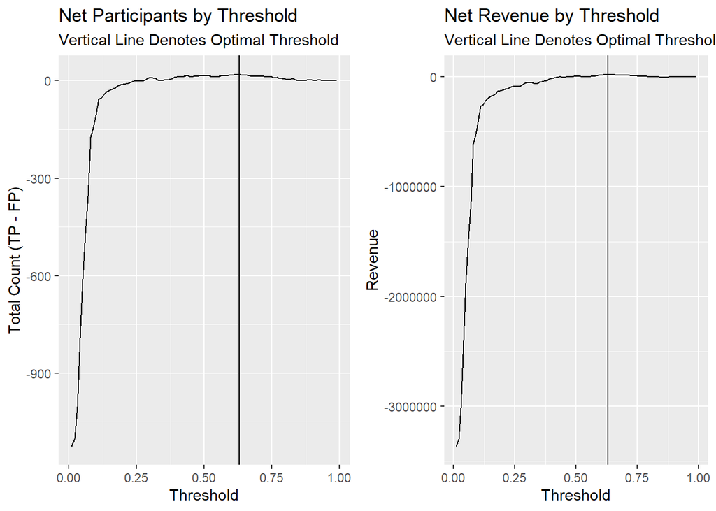

```r
whichThreshold_revenue <-
whichThreshold %>%
    group_by(Threshold) %>%
    summarize(Revenue = sum(Revenue))%>%
    round(digits=2)

revOptimalPlot <-
  ggplot(whichThreshold_revenue)+
geom_line(aes(x = Threshold, y = Revenue))+
geom_vline(xintercept =  pull(arrange(whichThreshold_revenue, -Revenue)[1,1]))+
  labs(title = "Net Revenue by Threshold",
       subtitle = "Vertical Line Denotes Optimal Threshold")

whichThreshold_counts <-
    whichThreshold%>%
    group_by(Threshold)%>%
    mutate(TotalCount = ifelse(Variable == "True_Negative", 0,
                     ifelse(Variable == "True_Positive", Count,
               ifelse(Variable == "False_Negative", 0,
               ifelse(Variable == "False_Positive", Count * -1, 0)))))%>%
    summarize(TotalCount = sum(TotalCount))%>%
  round(digits=2)

Optimal_Threshold <- pull(arrange(whichThreshold_counts, -TotalCount)[1,1])

countOptimalPlot <-
    ggplot(whichThreshold_counts)+
geom_line(aes(x = Threshold, y = TotalCount))+
geom_vline(xintercept =  pull(arrange(whichThreshold_counts, -TotalCount)[1,1]))+
  labs(title = "Net Participants by Threshold",
       subtitle = "Vertical Line Denotes Optimal Threshold",
       y= "Total Count (TP - FP)")

grid.arrange(countOptimalPlot, revOptimalPlot, ncol=2)
```

## Optimal Thresholds

Create a table of the Total_Revenue and Total_Count_of_Credits allocated for 2 categories. 50%_Threshold and your Optimal_Threshold.

```r
whichThreshold_Summary <-
  whichThreshold_counts %>%
  left_join(whichThreshold_revenue, by="Threshold")%>%
  filter(Threshold == 0.50 | Threshold == Optimal_Threshold)

whichThreshold_Summary%>%
  kable(
    caption = "<strong></strong>",
    escape= FALSE,
    format="html",
    row.names = FALSE,
    align="l")%>%
  kable_styling()
```

| Threshold | TotalCount | Revenue |
| --- | --- | --- |
| 0.50 | 15 | 4370 |
| 0.63 | 20 | 24680 |

# Conclusion